# marketing_campaign

## 1. Import the datasets and libraries, check datatype, statistical summary, shape, null values

Bank is has a growing customer base. The bank wants to increase borrowers (asset customers) base to bring in more loan business and earn more through the interest on loans. So , bank wants to convert the liability based customers to personal loan customers. (while retaining them as depositors). A campaign that the bank ran last year for liability customers showed a healthy conversion rate of over 9% success. The department wants to build a model that will help them identify the potential customers who have higher probability of purchasing the loan. This will increase the success ratio while at the same time reduce the cost of the campaign.

```python
import pandas as pd
import numpy as np
import matplotlib.pyplot as plt
import seaborn as sns
from sklearn.preprocessing import PowerTransformer
from sklearn.model_selection import train_test_split
from sklearn.linear_model import LogisticRegression
from sklearn.tree import DecisionTreeClassifier
from sklearn.ensemble import RandomForestClassifier
from sklearn.naive_bayes import GaussianNB
from sklearn.neighbors import KNeighborsClassifier
from sklearn.metrics import classification_report, confusion_matrix, accuracy_score, roc_auc_score
```

After importing all the necessary libraries, now we have to import the data.

```python
data = pd.read_csv('Bank_Personal_Loan_Modelling.csv')
data.head()
```

|  | ID | Age | Experience | Income | ZIP Code | Family | CCAvg | Education | Mortgage | Personal Loan | Securities Account | CD Account | Online | CreditCard |
| --- | --- | --- | --- | --- | --- | --- | --- | --- | --- | --- | --- | --- | --- | --- |
| 0 | 1 | 25 | 1 | 49 | 91107 | 4 | 1.6 | 1 | 0 | 0 | 1 | 0 | 0 | 0 |
| 1 | 2 | 45 | 19 | 34 | 90089 | 3 | 1.5 | 1 | 0 | 0 | 1 | 0 | 0 | 0 |
| 2 | 3 | 39 | 15 | 11 | 94720 | 1 | 1.0 | 1 | 0 | 0 | 0 | 0 | 0 | 0 |
| 3 | 4 | 35 | 9 | 100 | 94112 | 1 | 2.7 | 2 | 0 | 0 | 0 | 0 | 0 | 0 |
| 4 | 5 | 35 | 8 | 45 | 91330 | 4 | 1.0 | 2 | 0 | 0 | 0 | 0 | 0 | 1 |

The file given below contains data on 5000 customers. The data include customer demographic information (age, income, etc.), the customer's relationship with the bank (mortgage, securities account, etc.), and the customer response to the last personal loan campaign (Personal Loan). Among these 5000 customers, only 480 (= 9.6%) accepted the personal loan that was offered to them in the earlier campaign

```python
data.info()
```

```
<class 'pandas.core.frame.DataFrame'>
RangeIndex: 5000 entries, 0 to 4999
Data columns (total 14 columns):
 #   Column              Non-Null Count  Dtype
---  ------              --------------  -----
 0   ID                  5000 non-null   int64
 1   Age                 5000 non-null   int64
 2   Experience          5000 non-null   int64
 3   Income              5000 non-null   int64
 4   ZIP Code            5000 non-null   int64
 5   Family              5000 non-null   int64
 6   CCAvg               5000 non-null   float64
 7   Education           5000 non-null   int64
 8   Mortgage            5000 non-null   int64
 9   Personal Loan       5000 non-null   int64
 10  Securities Account  5000 non-null   int64
 11  CD Account          5000 non-null   int64
 12  Online              5000 non-null   int64
 13  CreditCard          5000 non-null   int64
dtypes: float64(1), int64(13)
memory usage: 547.0 KB
```

```python
data.describe()
```

|  | ID | Age | Experience | Income | ZIP Code | Family | CCAvg | Education | Mortgage | Personal Loan | Securities Account | CD Account | Online | CreditCard |
| --- | --- | --- | --- | --- | --- | --- | --- | --- | --- | --- | --- | --- | --- | --- |
| count | 5000.000000 | 5000.000000 | 5000.000000 | 5000.000000 | 5000.000000 | 5000.000000 | 5000.000000 | 5000.000000 | 5000.000000 | 5000.000000 | 5000.000000 | 5000.00000 | 5000.000000 | 5000.000000 |
| mean | 2500.500000 | 45.338400 | 20.104600 | 73.774200 | 93152.503000 | 2.396400 | 1.937938 | 1.881000 | 56.498800 | 0.096000 | 0.104400 | 0.06040 | 0.596800 | 0.294000 |
| std | 1443.520003 | 11.463166 | 11.467954 | 46.033729 | 2121.852197 | 1.147663 | 1.747659 | 0.839869 | 101.713802 | 0.294621 | 0.305809 | 0.23825 | 0.490589 | 0.455637 |
| min | 1.000000 | 23.000000 | -3.000000 | 8.000000 | 9307.000000 | 1.000000 | 0.000000 | 1.000000 | 0.000000 | 0.000000 | 0.000000 | 0.00000 | 0.000000 | 0.000000 |
| 25% | 1250.750000 | 35.000000 | 10.000000 | 39.000000 | 91911.000000 | 1.000000 | 0.700000 | 1.000000 | 0.000000 | 0.000000 | 0.000000 | 0.00000 | 0.000000 | 0.000000 |
| 50% | 2500.500000 | 45.000000 | 20.000000 | 64.000000 | 93437.000000 | 2.000000 | 1.500000 | 2.000000 | 0.000000 | 0.000000 | 0.000000 | 0.00000 | 1.000000 | 0.000000 |
| 75% | 3750.250000 | 55.000000 | 30.000000 | 98.000000 | 94608.000000 | 3.000000 | 2.500000 | 3.000000 | 101.000000 | 0.000000 | 0.000000 | 0.00000 | 1.000000 | 1.000000 |
| max | 5000.000000 | 67.000000 | 43.000000 | 224.000000 | 96651.000000 | 4.000000 | 10.000000 | 3.000000 | 635.000000 | 1.000000 | 1.000000 | 1.00000 | 1.000000 | 1.000000 |

- Observation: Our dataset need some cleaning as the Experience column has some negative values, and it's not possible for experience to be negative.

```python
print(f'Shape of dataset is  {data.shape}')
```

```
Shape of dataset is  (5000, 14)
```

```python
data.isnull().sum()
```

```
ID                    0
Age                   0
Experience            0
Income                0
ZIP Code              0
Family                0
CCAvg                 0
Education             0
Mortgage              0
Personal Loan         0
Securities Account    0
CD Account            0
Online                0
CreditCard            0
dtype: int64
```

## 2. Check if you need to clean the data for any of the variables

```python
print(f'Negative values = {len(data.Experience[data.Experience<0])}')
print(f'Correlation b/w Age & Experience = {data.Experience.corr(data.Age)}')
```

```
Negative values = 52
Correlation b/w Age & Experience = 0.9942148569683316
```

- We have a total of 52 ngative values in the dataset and
- Since the correlation is very high, so we prefer to drop the experience column.

```python
data.drop(['ID','Experience','ZIP Code'], axis=1, inplace= True )
data.head()
```

|  | Age | Income | Family | CCAvg | Education | Mortgage | Personal Loan | Securities Account | CD Account | Online | CreditCard |
| --- | --- | --- | --- | --- | --- | --- | --- | --- | --- | --- | --- |
| 0 | 25 | 49 | 4 | 1.6 | 1 | 0 | 0 | 1 | 0 | 0 | 0 |
| 1 | 45 | 34 | 3 | 1.5 | 1 | 0 | 0 | 1 | 0 | 0 | 0 |
| 2 | 39 | 11 | 1 | 1.0 | 1 | 0 | 0 | 0 | 0 | 0 | 0 |
| 3 | 35 | 100 | 1 | 2.7 | 2 | 0 | 0 | 0 | 0 | 0 | 0 |
| 4 | 35 | 45 | 4 | 1.0 | 2 | 0 | 0 | 0 | 0 | 0 | 1 |

## 3. EDA: Study the data distribution in each attribute and target variable, share your findings.

### ● Number of unique in each column?

```python
data.nunique()
```

```
Age                    45
Income                162
Family                  4
CCAvg                 108
Education               3
Mortgage              347
Personal Loan           2
Securities Account      2
CD Account              2
Online                  2
CreditCard              2
dtype: int64
```

### ● Number of people with zero mortgage?

```python
(data['Mortgage']==0).sum()
```

```
3462
```

### ● Number of people with zero credit card spending per month?

```python
(data['CCAvg']==0).sum()
```

```
106
```

### ● Value counts of all categorical columns.

```python
(data['Personal Loan']==0).sum()
```

```
4520
```

```python
data['Family'].value_counts()
```

```
1    1472
2    1296
4    1222
3    1010
Name: Family, dtype: int64
```

```python
data['Education'].value_counts()
```

```
1    2096
3    1501
2    1403
Name: Education, dtype: int64
```

```python
data['Personal Loan'].value_counts()
```

```
0    4520
1     480
Name: Personal Loan, dtype: int64
```

```python
data['Securities Account'].value_counts()
```

```
0    4478
1     522
Name: Securities Account, dtype: int64
```

```python
data['CD Account'].value_counts()
```

```
0    4698
1     302
Name: CD Account, dtype: int64
```

```python
data['Online'].value_counts()
```

```
1    2984
0    2016
Name: Online, dtype: int64
```

```python
data['CreditCard'].value_counts()
```

```
0    3530
1    1470
Name: CreditCard, dtype: int64
```

### ● Univariate Analysis

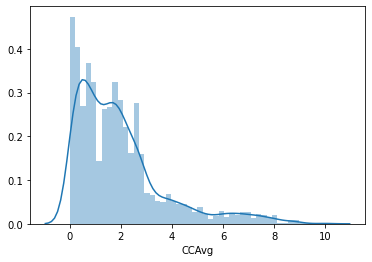

```python
sns.distplot(data.CCAvg)
```

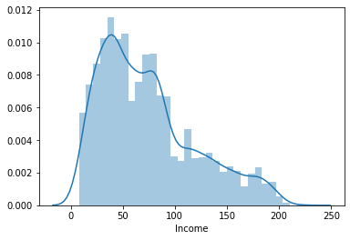

```python
sns.distplot(data.Income)
```

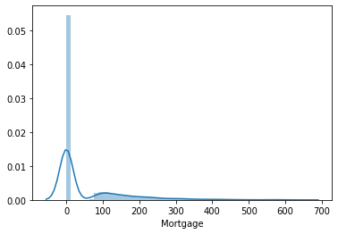

```python
sns.distplot(data.Mortgage)
```

- Observation: Since the above 3 variables are not normalised, so we need to perform some transformations to normalise them.

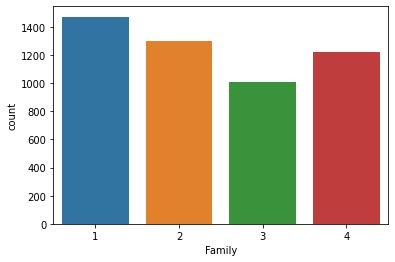

```python
sns.countplot(x='Family', data=data)
```

- Observation: Comparatively more people in our dataset are single.

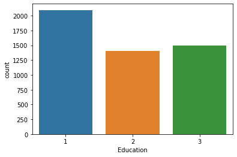

```python
sns.countplot(x='Education', data=data)
```

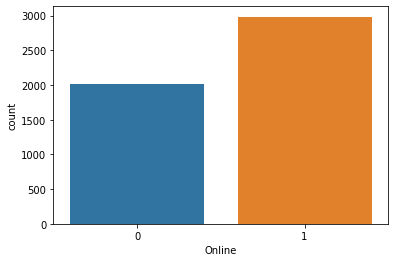

```python
sns.countplot(x='Online', data=data)
```

- Observation: Most of the customers have the internet banking facility.

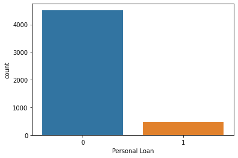

```python
sns.countplot(x='Personal Loan', data=data)
```

- Observation: Here we can see that very few people opted for Personal Loan.

### ● Multivariate Analysis

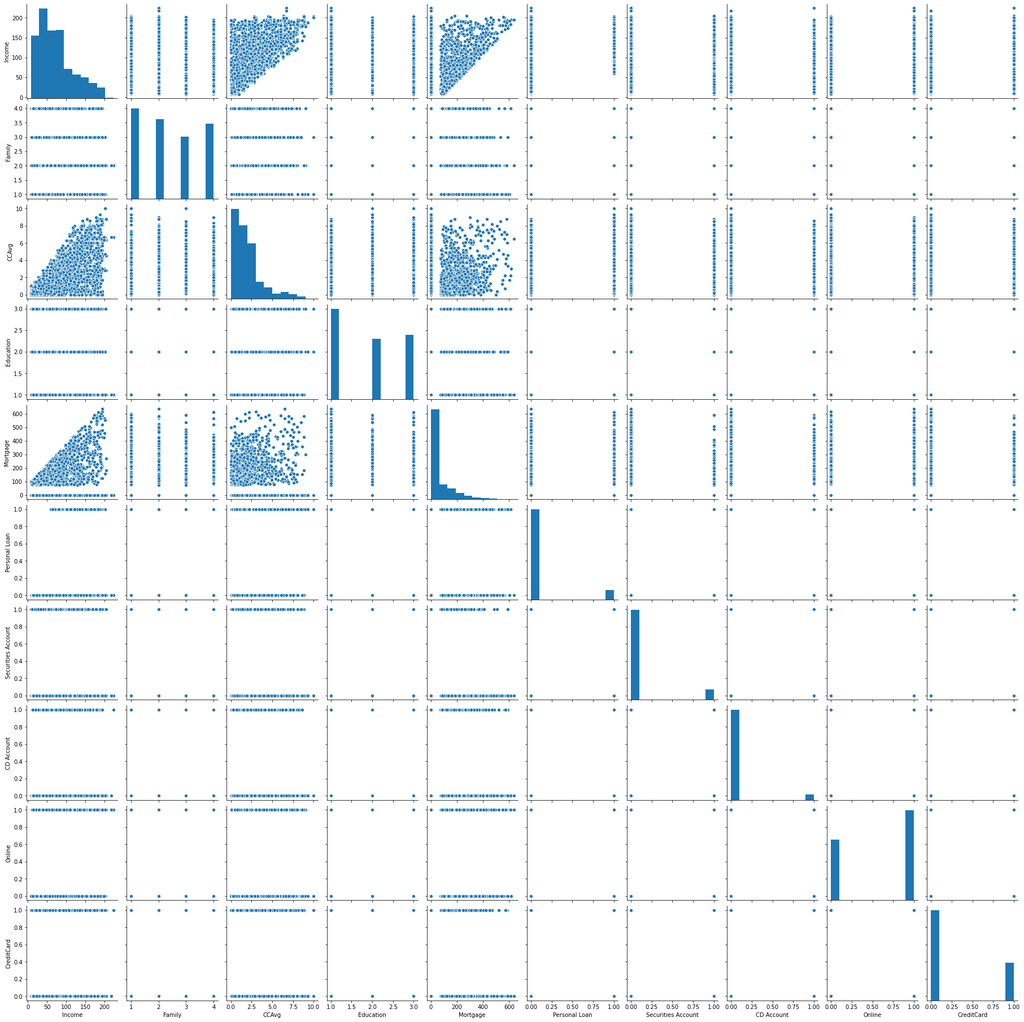

```python
sns.pairplot(data.iloc[:,1:])
```

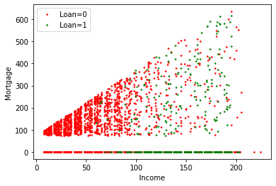

```python
i0 = data['Personal Loan']==0
i1 = data['Personal Loan']==1
plt.plot(data['Income'][i0],data['Mortgage'][i0],'ro', markersize=1.5,label= 'Loan=0')
plt.plot(data['Income'][i1],data['Mortgage'][i1],'go', markersize=1.5,label= 'Loan=1')
plt.xlabel('Income')
plt.ylabel('Mortgage')
plt.legend()
plt.show()
```

- Observation: It's clear from the graph that person with high income has high mortgage and person who has taken loan has both Income and mortgage are high.

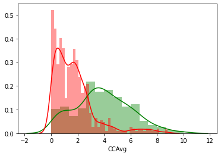

```python
sns.distplot(data.CCAvg[data['Personal Loan']==1], color ='g')
sns.distplot(data.CCAvg[data['Personal Loan']==0], color ='r')
```

- Observation: Above graph shows that person who has taken the loan has higher credit card average.

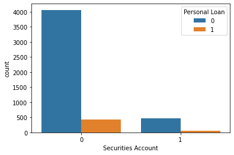

```python
sns.countplot(x='Securities Account', hue='Personal Loan', data=data)
```

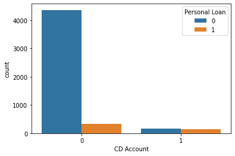

```python
sns.countplot(x='CD Account', hue='Personal Loan', data=data)
```

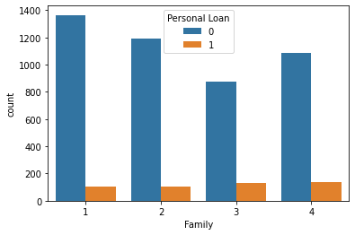

```python
sns.countplot(x='Family', hue='Personal Loan', data=data)
```

- Observation: Seems like Family size does not have impact on loan, so it's better to drop family column

```python
data.drop('Family', axis=1, inplace=True)
```

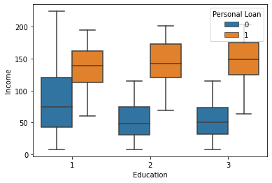

```python
sns.boxplot(x='Education', y='Income',hue='Personal Loan', data=data)
```

- Observation: Person opted for loan have same level of income.

## 4. Apply necessary transformations for the feature variables

We are using yeo-johnson transformation for Income and CCAvg columns

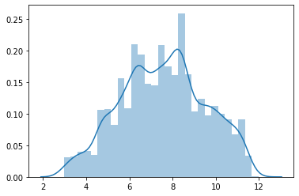

```python
pt = PowerTransformer(standardize=False)
pt.fit(data.Income.values.reshape(-1,1))
temp = pt.transform(data.Income.values.reshape(-1,1))
data['Income_t'] = temp
sns.distplot(temp)
```

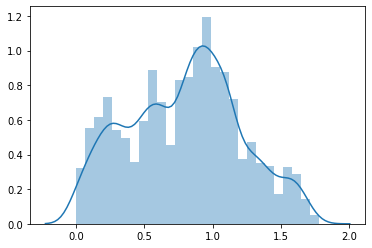

```python
pt = PowerTransformer(standardize=False)
pt.fit(data.CCAvg.values.reshape(-1,1))
temp = pt.transform(data.CCAvg.values.reshape(-1,1))
data['CCAvg_t'] = temp
sns.distplot(temp)
```

- Observation: As we can observe that these are now looking more normal, so now we have to drop our old Income and CCAvg columns .

```python
data.drop(['Income', 'CCAvg'], axis=1, inplace=True)
```

- We can not use yeo-johnson transformation here because we have 347 different values here and most of them are towards zero, so we are using Binning here.

```python
data['Mortgage_int'] = pd.cut(data.Mortgage, bins= [0,100,200,300,400,500,600,700], labels= [0,1,2,3,4,5,6],include_lowest=True)
data.drop('Mortgage', axis =1, inplace=True)
```

```python
data.head()
```

|  | Age | Education | Personal Loan | Securities Account | CD Account | Online | CreditCard | Income_t | CCAvg_t | Mortgage_int |
| --- | --- | --- | --- | --- | --- | --- | --- | --- | --- | --- |
| 0 | 25 | 1 | 0 | 1 | 0 | 0 | 0 | 6.827583 | 0.845160 | 0 |
| 1 | 45 | 1 | 0 | 1 | 0 | 0 | 0 | 5.876952 | 0.814478 | 0 |
| 2 | 39 | 1 | 0 | 0 | 0 | 0 | 0 | 3.504287 | 0.633777 | 0 |
| 3 | 35 | 2 | 0 | 0 | 0 | 0 | 0 | 8.983393 | 1.107427 | 0 |
| 4 | 35 | 2 | 0 | 0 | 0 | 0 | 1 | 6.597314 | 0.633777 | 0 |

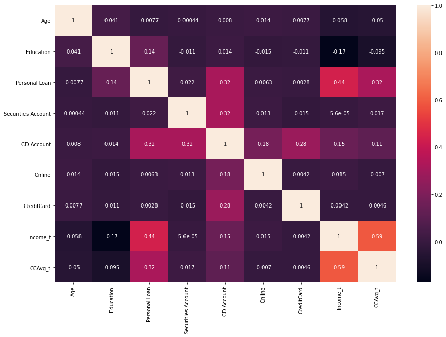

```python
fig, ax = plt.subplots(figsize=(15,10))
sns.heatmap(data.corr(), annot=True)
```

- Observation: we can see here that personal loan correlates with CCAvg, Income, CD Account the most.

## 5. Split you dataset into Train Test Split

- It's time to split our dataset into training and testing sets
- First we divide our dataframe into X and Y

```python
X = data.drop('Personal Loan', axis=1)
y = data[['Personal Loan']]
```

```python
#Shape of X and y
print(f'X = {X.shape}')
print(f'y = {y.shape}')
```

```
X = (5000, 9)
y = (5000, 1)
```

- Splitting the dataset into 70:30 ratio for training and testing, also using stratify in order to maintain the percentage of true values.

```python
 X_train, X_test, y_train, y_test = train_test_split(X, y, test_size=0.3, stratify = y, random_state=1)
```

```python
print(f'X_train = {X_train.shape}')
print(f'y_train = {y_train.shape}')
print(f'X_test = {X_test.shape}')
print(f'y_test = {y_test.shape}')
```

```
X_train = (3500, 9)
y_train = (3500, 1)
X_test = (1500, 9)
y_test = (1500, 1)
```

## 6. Prediction Models and Comparisons

### ● Logistic Regression Model

Logistic regression is a statistical model that in its basic form uses a logistic function to model a binary dependent variable, although many more complex extensions exist

```python
LR_model = LogisticRegression(fit_intercept=True, random_state=1, max_iter=250)
LR_model.fit(X_train, np.array(y_train).ravel())
LR_predict = LR_model.predict(X_test)
LR_train_acc = LR_model.score(X_train,y_train)
LR_test_acc = LR_model.score(X_test,y_test)
```

```python
print(f'LogisticRegression Train Accuracy = {LR_train_acc}')
print(f'LogisticRegression Test Accuracy = {LR_test_acc}\n\n')
print(classification_report(y_test, LR_predict, target_names=['0','1']))
print(f'ROC AUC Score = {roc_auc_score(y_test, LR_predict)}')
```

```
LogisticRegression Train Accuracy = 0.9562857142857143
LogisticRegression Test Accuracy = 0.9486666666666667


              precision    recall  f1-score   support

           0       0.96      0.99      0.97      1356
           1       0.82      0.60      0.69       144

    accuracy                           0.95      1500
   macro avg       0.89      0.79      0.83      1500
weighted avg       0.95      0.95      0.95      1500

ROC AUC Score = 0.7916052114060964
```

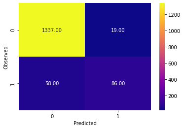

```python
sns.heatmap(confusion_matrix(y_test, LR_predict), fmt='0.2f', annot=True , cmap='plasma')
plt.ylabel('Observed')
plt.xlabel('Predicted')
plt.show()
```

### ● Decision Tree Model

Decision tree learning is one of the predictive modelling approaches used in statistics, data mining and machine learning. It uses a decision tree (as a predictive model) to go from observations about an item (represented in the branches) to conclusions about the item's target value (represented in the leaves). Tree models where the target variable can take a discrete set of values are called classification trees, we are using classification tree here.

```python
dt_model = DecisionTreeClassifier(criterion='entropy', max_depth=6,random_state=1)
dt_model.fit(X_train, y_train)
dt_predict = dt_model.predict(X_test)
dt_train_acc = dt_model.score(X_train,y_train)
dt_test_acc = dt_model.score(X_test,y_test)
```

```python
print(f'DecisionTreeClassifier Train Accuracy = {dt_train_acc}')
print(f'DecisionTreeClassifier Test Accuracy = {dt_test_acc}\n\n')
print(classification_report(y_test, dt_predict, target_names=['0','1']))
print(f'ROC AUC Score = {roc_auc_score(y_test, dt_predict)}')
```

```
DecisionTreeClassifier Train Accuracy = 0.9788571428571429
DecisionTreeClassifier Test Accuracy = 0.9733333333333334


              precision    recall  f1-score   support

           0       0.97      1.00      0.99      1356
           1       0.96      0.76      0.84       144

    accuracy                           0.97      1500
   macro avg       0.97      0.88      0.92      1500
weighted avg       0.97      0.97      0.97      1500

ROC AUC Score = 0.876628564405113
```

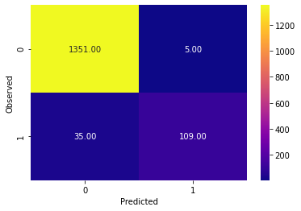

```python
sns.heatmap(confusion_matrix(y_test, dt_predict), fmt='0.2f', annot=True , cmap='plasma')
plt.ylabel('Observed')
plt.xlabel('Predicted')
plt.show()
```

### ● Random Forest Model

Random forests or random decision forests are an ensemble learning method for classification, regression and other tasks that operate by constructing a multitude of decision trees at training time and outputting the class that is the mode of the classes or mean prediction of the individual trees.

```python
rf_model = RandomForestClassifier(criterion='entropy', max_depth=9,random_state=1)
rf_model.fit(X_train, np.array(y_train).ravel())
rf_predict = rf_model.predict(X_test)
rf_train_acc = rf_model.score(X_train,y_train)
rf_test_acc = rf_model.score(X_test,y_test)
```

```python
print(f'RandomForestClassifier Train Accuracy = {rf_train_acc}')
print(f'RandomForestClassifier Test Accuracy = {rf_test_acc}\n\n')
print(classification_report(y_test, rf_predict, target_names=['0','1']))
print(f'ROC AUC Score = {roc_auc_score(y_test, rf_predict)}')
```

```
RandomForestClassifier Train Accuracy = 0.9868571428571429
RandomForestClassifier Test Accuracy = 0.9706666666666667


              precision    recall  f1-score   support

           0       0.97      1.00      0.98      1356
           1       0.95      0.74      0.83       144

    accuracy                           0.97      1500
   macro avg       0.96      0.87      0.91      1500
weighted avg       0.97      0.97      0.97      1500

ROC AUC Score = 0.8658431661750245
```

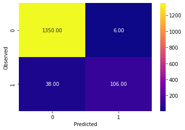

```python
sns.heatmap(confusion_matrix(y_test, rf_predict), fmt='0.2f', annot=True , cmap='plasma')
plt.ylabel('Observed')
plt.xlabel('Predicted')
plt.show()
```

### ● Naive Bayes

In statistics, Naive Bayes classifiers are a family of simple "probabilistic classifiers" based on applying Bayes' theorem with strong independence assumptions between the features. They are among the simplest Bayesian network models

```python
naive_model = GaussianNB()
naive_model.fit(X_train, np.array(y_train).ravel())
naive_predict = naive_model.predict(X_test)
naive_train_acc = naive_model.score(X_train,y_train)
naive_test_acc = naive_model.score(X_test,y_test)
```

```python
print(f'Naive Bayes Train Accuracy = {naive_train_acc}')
print(f'Naive Bayes Test Accuracy = {naive_test_acc}\n\n')
print(classification_report(y_test, naive_predict, target_names=['0','1']))
print(f'ROC AUC Score = {roc_auc_score(y_test, naive_predict)}')
```

```
Naive Bayes Train Accuracy = 0.9117142857142857
Naive Bayes Test Accuracy = 0.9166666666666666


              precision    recall  f1-score   support

           0       0.95      0.96      0.95      1356
           1       0.57      0.56      0.56       144

    accuracy                           0.92      1500
   macro avg       0.76      0.76      0.76      1500
weighted avg       0.92      0.92      0.92      1500

ROC AUC Score = 0.7552851524090463
```

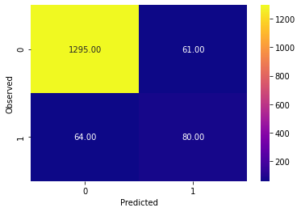

```python
sns.heatmap(confusion_matrix(y_test, naive_predict), fmt='0.2f', annot=True , cmap='plasma')
plt.ylabel('Observed')
plt.xlabel('Predicted')
plt.show()
```

## ● KNN

The k-nearest neighbors algorithm (k-NN) is a non-parametric method proposed by Thomas Cover used for classification and regression. In both cases, the input consists of the k closest training examples in the feature space. The output depends on whether k-NN is used for classification or regression, we are using it here for classification.

```python
knn_model = KNeighborsClassifier(n_neighbors= 15)
knn_model.fit(X_train, np.array(y_train).ravel())
knn_predict = knn_model.predict(X_test)
knn_train_acc = knn_model.score(X_train,y_train)
knn_test_acc = knn_model.score(X_test,y_test)
```

```python
print(f'KNN Train Accuracy = {knn_train_acc}')
print(f'KNN Test Accuracy = {knn_test_acc}\n\n')
print(classification_report(y_test, knn_predict, target_names=['0','1']))
print(f'ROC AUC Score = {roc_auc_score(y_test, knn_predict)}')
```

```
KNN Train Accuracy = 0.9502857142857143
KNN Test Accuracy = 0.936


              precision    recall  f1-score   support

           0       0.94      1.00      0.97      1356
           1       0.94      0.35      0.52       144

    accuracy                           0.94      1500
   macro avg       0.94      0.68      0.74      1500
weighted avg       0.94      0.94      0.92      1500

ROC AUC Score = 0.675977138643068
```

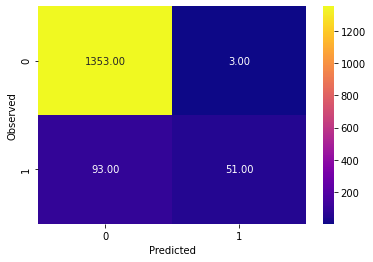

```python
sns.heatmap(confusion_matrix(y_test, knn_predict), fmt='0.2f', annot=True , cmap='plasma')
plt.ylabel('Observed')
plt.xlabel('Predicted')
plt.show()
```

## 7. Business understanding of our model

> We have started our project by importing important libraries and importing our dataset as well, talking about the dataset, it consists of data on 5000 customers. The data include customer demographic information (age, income, etc.), the customer's relationship with the bank (mortgage, securities account, etc.), and the customer response to the last personal loan campaign (Personal Loan).

> Among these 5000 customers, only 480 (= 9.6%) accepted the personal loan that was offered to them in the earlier campaign.

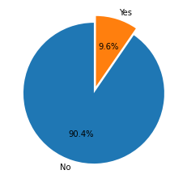

```python
plt.pie(data['Personal Loan'].value_counts(), labels= ['No','Yes'],autopct='%1.1f%%',startangle=90,explode=[0,0.1])
plt.show()
```

> So our goal is to make a model to predict whether a customer will take personal loan or not.

> The first step after importing the data set is to clean the values that are not suitable, like we have found that experience column has negative values and it is highly correlated to the age column so we have dropped the experience column.

> Also ID and Zip code does not contribute to the prediction of personal loan, so we've dropped them.

> Since the Mortgage column is discrete, so instead of using power transformation we have to use the binning technique here.

> Family column also doesn't have a impact on Personal Loan verdict so we have dropped it also.

> After that we have tried 5 different model on the data, results are here.

| Model | Accuracy | Precision | Recall | F1 | AUC |
| --- | --- | --- | --- | --- | --- |
| Logistic Reg | 0.95 | 0.82 | 0.60 | 0.69 | 0.79 |
| Decision Tree | 0.97 | 0.96 | 0.76 | 0.84 | 0.87 |
| Random Forest | 0.97 | 0.95 | 0.74 | 0.83 | 0.86 |
| Naive Bayes | 0.92 | 0.57 | 0.56 | 0.56 | 0.75 |
| KNN | 0.94 | 0.94 | 0.35 | 0.52 | 0.67 |

> Here, best results are provided by the Decision Tree model, so we have choosed it for our final business model.  
> Now lets see some insights of the classifier.

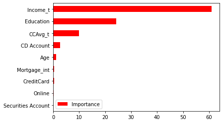

```python
Importance = pd.DataFrame({'Importance':dt_model.feature_importances_*100}, index=X_train.columns)
Importance.sort_values('Importance', axis=0, ascending=True).plot(kind='barh', color='r', );plt.show()
```